# Week 5 assignment

```python
import pandas as pd
from sklearn.cluster import KMeans
import matplotlib.pyplot as plt
from sklearn.cluster import BisectingKMeans
from sklearn.cluster import DBSCAN
from sklearn.preprocessing import StandardScaler
```

## Question 1. Apply KMeans (K=3) to the **Iris dataset** (excluding the "class" attribute). Use 'petal width' and 'sepal length' to create a scatter plot and use cluster label as color. [10 points]

- Code (5 points)
- Scatter plot (5 points)

```python
iris = pd.read_csv('iris.txt', header=None)
iris.columns = ['sepal-L', 'sepal-W', 'petal-L', 'petal-W', 'class']
features = ['sepal-L', 'sepal-W', 'petal-L', 'petal-W']
X = iris[features]

k_means = KMeans(n_clusters=3)
k_means.fit(X)
iris['Cluster ID Q1']=k_means.labels_
iris.head()
```

|  | sepal-L | sepal-W | petal-L | petal-W | class | Cluster ID Q1 |
| --- | --- | --- | --- | --- | --- | --- |
| 0 | 5.1 | 3.5 | 1.4 | 0.2 | Iris-setosa | 2 |
| 1 | 4.9 | 3.0 | 1.4 | 0.2 | Iris-setosa | 2 |
| 2 | 4.7 | 3.2 | 1.3 | 0.2 | Iris-setosa | 2 |
| 3 | 4.6 | 3.1 | 1.5 | 0.2 | Iris-setosa | 2 |
| 4 | 5.0 | 3.6 | 1.4 | 0.2 | Iris-setosa | 2 |

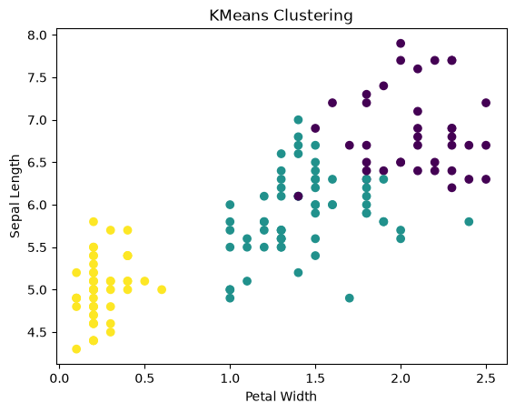

```python
# Scatter plot using 'petal width' and 'sepal length'
plt.scatter(iris['petal-W'], iris['sepal-L'], c=iris['Cluster ID Q1'],
    cmap='viridis')
plt.xlabel('Petal Width')
plt.ylabel('Sepal Length')
plt.title('KMeans Clustering')
plt.show()
```

## Question 2. Apply BisectingKMeans (K=3) to the **Iris dataset** (excluding the "class" attribute). Briefly explain how its hierarchical partitioning mechanism differs from standard K-means. Reference link: BisectingKMeans [20 points]

- Code (15 points)
- Scatter plot or explanation of mechanism (5 points)

#### Bisecting K-Means uses a hierarchical top-down approach: it starts with one cluster and repeatedly splits an existing cluster into two using K-Means until K clusters are obtained.

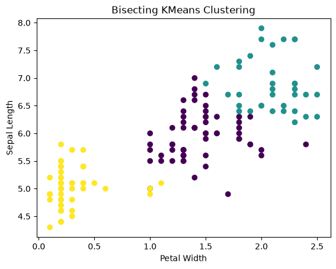

```python
bkm = BisectingKMeans(n_clusters=3)
bkm.fit(X)
iris['Cluster ID Q2']=bkm.labels_

plt.scatter(iris['petal-W'], iris['sepal-L'], c=iris['Cluster ID Q2'],
    cmap='viridis')
plt.xlabel('Petal Width')
plt.ylabel('Sepal Length')
plt.title('Bisecting KMeans Clustering')
plt.show()
```

## Question 3. Choose one density-based clustering algorithm and present the clustering results on the **Iris dataset** (excluding the "class" attribute). Tune its parameters and identify how many data points are classified as noise. [20 points]

- Code (15 points)
- Noise points (5 points)

```
Number of noise points:  17
```

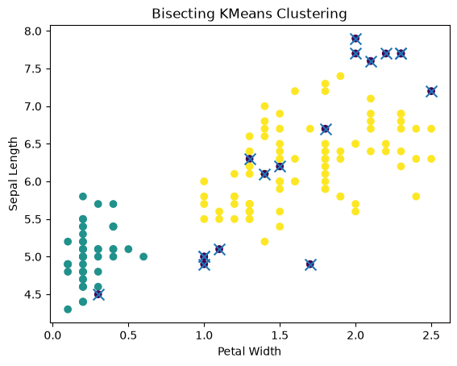

```python
db = DBSCAN(eps=0.5, min_samples=5).fit(X)
iris['Cluster ID Q3']=db.labels_
plt.scatter(iris['petal-W'], iris['sepal-L'], c=iris['Cluster ID Q3'],
    cmap='viridis')

print("Number of noise points: ", iris.loc[iris['Cluster ID Q3']==-1].shape[0])
noise = iris[iris['Cluster ID Q3'] == -1]

plt.scatter(
    noise['petal-W'],
    noise['sepal-L'],
    marker='x',
    s=100,
    label='Noise'
)

plt.xlabel('Petal Width')
plt.ylabel('Sepal Length')
plt.title('Bisecting KMeans Clustering')
plt.show()
```

## Question 4. Based on the 4x4 grid plot in Section 2.5 of the tutorial (Moons, Blobs, Varied, Aniso), summarize which linkage method (Single, Average, Complete, or Ward's) is most suitable for which type of data shape, and state your final rule of thumb for selecting a linkage method. [20 points]

- Moons: **Single linkage** (5 points) is most suitable because it can capture **non-convex, connected, and curved structures** (5 points).
- Blobs: **Ward’s linkage** (5 points) works well for **compact, spherical, similar-sized clusters** because it tends to minimize within-cluster variance (5 points).
- Varied: **Average linkage** (5 points) is suitable for clusters with **different spreads and variances (different size)**, providing a balance between single and complete linkage (5 points). (or **Ward’s linkage** will also get points)
- Aniso: **Average linkage** (5 points) can be suitable for **elongated or anisotropic clusters** with **different spreads and variances (different size)** (5 points). (or **Complete linkage** or **Ward’s linkage** or even **Single linkage** will also get points, since there is no perfect one for Aniso)
- If you only explain the four types of linkage without identifying which type is most suitable for each dataset, deduct 2 points for each dataset.

## Question 5. Review and compare different clustering algorithms and choose one clustering algorithm for your course project dataset. Reference link: [Clustering Algorithms](https://scikit-learn.org/stable/auto_examples/cluster/plot_cluster_comparison.html#sphx-glr-auto-examples-cluster-plot-cluster-comparison-py) [30 points]

You can choose one of them to get full points:

- Review and compare different clustering algorithms and discuss your project with evidence to support which algorithm is most appropriate
- Provide detailed code for the project dataset and discuss the algorithms